# R / git / GitHub

March 9, 2017

## Welcome to R-Ladies RTP!

## Materials

- All source code at https://github.com/rladies/rtp_20170309_shiny
  - Download the contents of the repo, we'll need the R scripts and data in the apps folder
- Slides at http://rpubs.com/mine/rladies-shiny-reactivity101

## Reactivity 101

## Reactions

The `input$` list stores the current value of each input object under its name

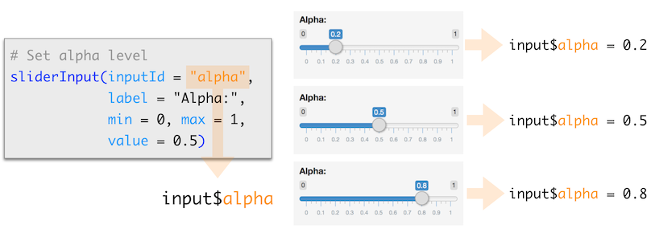

## Reactivity 101

Reactivity automatically occurs when an `input` value is used to render an `output` object

```r
# Define server function required to create the scatterplot --------
server <- function(input, output) {
  # Create the scatterplot object the plotOutput function is expecting
  output$scatterplot <- renderPlot(
   ggplot(data = movies, aes_string(x = input$x, y = input$y,
                                    color = input$z)) +
     geom_point(alpha = input$alpha)
  )
}
```

## Let’s build a simple movie browser app!

`movies.Rdata`: Data from IMDB and Rotten Tomatoes on random sample of 651 movies released in the US between 1970 and 2014

`movies_01.R`: Single file app for browsing movies

## Exercise

- Start with `movies_01.R`
- Add a new `sliderInput` defining the size of points (ranging from 0 to 5), see https://shiny.rstudio.com/reference/shiny/latest/sliderInput.html for help with defining a `sliderInput`
- Use this variable in the geom of the `ggplot` function as the `size` argument
- Run the app to ensure that point sizes react when you move the slider
- Compare your code / output with the person sitting next to / nearby you

## Solution

See `movies_02.R`

## Demo

Suppose you want the option to plot only certain types of movies as well as report how many such movies are plotted:

1. Add a UI element for the user to select which type(s) of movies they want to plot
2. Filter for chosen title type and save as a new (reactive) expression
3. Use new data frame (which is reactive) for plotting
4. Use new data frame (which is reactive) also for reporting number of observations

## Demo - 1

1. Add a UI element for the user to select which type(s) of movies they want to plot

```r
# Select which types of movies to plot
checkboxGroupInput(inputId = "selected_type",
                   label = "Select movie type(s):",
                   choice = c("Documentary", "Feature Film", "TV Movie"),
                   selected = "Feature Film")
```

## Demo - 2

1. Filter for chosen title type and save the new data frame as a reactive expression

**before app:**

```r
library(dplyr)
```

**server:**

```r
# Create a subset of data filtering for chosen title types
movies_subset <- reactive({
  movies %>%
    filter(title_type %in% input$selected_type)
})
```

*Note:* `reactive({})` creates a cached expression that knows it is out of date when input changes

## Demo - 3

Use new data frame (which is reactive) for plotting

```r
# Create the scatterplot object the plotOutput function is expecting
output$scatterplot <- renderPlot({
  ggplot(data = movies_subset(), aes_string(x = input$x, y = input$y,
                                            color = input$z)) +
    geom_point(…) +
    …
})
```

*Note:* Cached - only re-run when inputs change

## Demo - 4

Use new data frame (which is reactive) also for printing number of observations

**ui:**

```r
mainPanel(
  ...
  # Print number of obs plotted
  textOutput(outputId = "n"),
  ...
  )
```

**server:**

```r
# Print number of movies plotted
output$n <- renderText({
    counts <- movies_subset() %>%
      group_by(title_type) %>%
      summarise(count = n()) %>%
      select(count) %>%
      unlist()
    paste("There are", counts, input$selected_type, "movies in this dataset.")
})
```

## Altogether

See `movies_03.R`

(also notice the little bit of HTML code, added for visual separation, in the `mainPanel`)

## When to use reactives

- By using a reactive expression for the subsetted data frame, we were able to get away with subsetting once and then using the result twice
- In general, reactive conductors let you
  - not repeat yourself (i.e. avoid copy-and-paste code) which is a maintenance boon
  - decompose large, complex (code-wise, not necessarily CPU-wise) calculations into smaller pieces to make them more understandable
- These benefits are similar to what happens when you decompose a large complex R script into a series of small functions that build on each other